# 第6回 データの加工（2）：データの集計と要約統計量の算出

行動計量学（行動科学分析法入門）

小野原 彩香

令和8年度

← 授業トップへ戻る

## 本日の目標

1. `group_by()` + `summarise()` でグループ別集計ができる
2. `count()` でカテゴリの頻度を集計できる
3. 集計結果を `ggplot2` でグラフ化できる

## 準備：パッケージの読み込み

この回のコードは，すべて `tidyverse` を読み込んだ状態で動きます。 RStudioを起動したら，**まずこれを実行してください。**

```r
library(tidyverse)
```

> 毎回必要です。読み込まないまま `filter()` や `ggplot()` を使うと， 「関数が見つかりません」というエラーになります。

## 1. summarise()：集計

`summarise()` はデータ全体を1行（または数行）に集約します。

> **書き方** `summarise(データ, 新しい列名 = 集計の式)`
> - **新しい列名** … 自分で決めます。**引用符なし**，`=` は1つだけ
> - **集計の式** … `mean(列名)` のように，**たくさんの値を1つにまとめる計算**

> 書き方は第5回の `mutate()` と同じですが，**出てくるものが違います。**

> |  | 入れたデータ | 出てくるもの |
> | --- | --- | --- |
> | `mutate()` | 83行 11列 | **83行** 12列（列が1つ増える） |
> | `summarise()` | 83行 11列 | **1行** 1列（集計結果だけ） |

> `summarise()` は，83個の数字を1個にまとめる関数です。 だから元の列（`name` や `vore`）は**消えて**，作った列だけが残ります。

```r
# msleep の全体の睡眠時間の平均
msleep |>
  summarise(mean_sleep = mean(sleep_total, na.rm = TRUE))
```

| mean_sleep |
| --- |
| 10.43373 |

```r
# 複数の統計量をまとめて計算
msleep |>
  summarise(
    n = n(),
    mean_sleep = mean(sleep_total, na.rm = TRUE),
    sd_sleep   = sd(sleep_total, na.rm = TRUE),
    min_sleep  = min(sleep_total, na.rm = TRUE),
    max_sleep  = max(sleep_total, na.rm = TRUE)
  )
```

| n | mean_sleep | sd_sleep | min_sleep | max_sleep |
| --- | --- | --- | --- | --- |
| 83 | 10.43373 | 4.450357 | 1.9 | 19.9 |

### よく使う集計関数

| 関数 | 意味 |
| --- | --- |
| `mean(x, na.rm=TRUE)` | 平均値 |
| `sd(x, na.rm=TRUE)` | 標準偏差 |
| `median(x, na.rm=TRUE)` | 中央値 |
| `min(x)` / `max(x)` | 最小値 / 最大値 |
| `n()` | データ件数 |
| `sum(x, na.rm=TRUE)` | 合計 |

> **書き方** `n()`

> **（）の中には何も書きません。** そのグループに何件あるか数えます。 `summarise()` の**中でしか使えません**。単独で `n()` と打つと， 「`mutate()` や `summarise()` の中で使ってください」というエラーになります。

> **`na.rm = TRUE` を忘れると，答えが `NA` になります。**

> ```r
> msleep |> summarise(m = mean(sleep_rem))                # NA
> msleep |> summarise(m = mean(sleep_rem, na.rm = TRUE))  # 1.875
> ```

> `sleep_rem`（REM睡眠時間）には欠損があります。 **欠損が1つでも混ざっていると，平均も「分からない」＝ `NA` になります。** Rは勝手に無視しません。「この中に分からない値がある」と正直に答えています。

> `na.rm = TRUE` は「**欠損を除いて計算してください**」という指示です。 便利ですが，**除いた結果である**ことは意識しておいてください。 何件除いたかは `sum(is.na(列名))` で数えられます。

> **Pythonを触ったことがある人へ。**

> pandasは逆の設計です。`Series.mean()` は**欠損を黙って無視して**計算します。 つまり `na.rm = TRUE` が最初から付いている状態です。

> ```
> pd.Series([1, 2, None, 4]).mean()   # 2.333... 欠損があっても答えが出る
> ```

> 一方，numpyの `np.mean()` や `statistics.mean()` は，Rと同じ `nan` を返します。 ライブラリごとに違うので，「Pythonはこう」とは言えません。

> どちらが正しいという話ではなく，**既定値がどちらに倒れているかの違い**です。 Rは「黙って答えない」側に倒してあります。

## 2. group_by() + summarise()：グループ別集計

`group_by()` と `summarise()` を組み合わせると，グループごとに集計できます。

> **書き方** `group_by(データ, 分ける基準の列)`
> - **分ける基準の列** … カテゴリの列（`vore` や `Species`）。引用符は要りません

> **`group_by()` だけでは，見た目はほとんど変わりません。** 行は83行のままで，表の上に1行増えるだけです。

> ```
> # A tibble: 83 × 11
> # Groups:   vore [5]
> ```

> この `# Groups: vore [5]` が「**5つのグループに分けました**」という印です。 分けただけで，まだ何も計算していません。 うしろに `summarise()` をつないで，はじめてグループごとの計算になります。
> - `msleep` … 83行
> - `msleep` にグループ分けだけ … 83行（5グループの印が付く）
> - そのあと `summarise()` … **5行**（グループごとに1行）

> `vore` は4種類しかないのに5グループなのは，**欠損の7件が1グループ**に まとめられるからです（すぐ下で説明します）。

```r
# 食性（vore）ごとの平均睡眠時間
msleep |>
  group_by(vore) |>
  summarise(
    n = n(),
    mean_sleep = mean(sleep_total, na.rm = TRUE),
    sd_sleep   = sd(sleep_total, na.rm = TRUE)
  )
```

| vore | n | mean_sleep | sd_sleep |
| --- | --- | --- | --- |
| carni | 19 | 10.378947 | 4.669116 |
| herbi | 32 | 9.509375 | 4.878746 |
| insecti | 5 | 14.940000 | 5.920557 |
| omni | 20 | 10.925000 | 2.949019 |
| NA | 7 | 10.185714 | 3.004124 |

### 出てきた `<NA>` の行は何か

出力の最後に `<NA>` という行があります。**これは「NAという食性」ではありません。** `msleep` には**食性が記録されていない動物が7種**あり，その7種がひとまとめにされて集計されています。

`group_by()` は，欠損値も1つのグループとして扱います。黙って捨てたりはしません。 「そういうデータがある」と見せてくれている，と考えてください。

> **この行をどう扱うかは，分析する人が決めます。**
> - 食性どうしを比べるのが目的なら，**除く**（4節でそうしています）
> - 「食性が不明な動物がこれだけいる」こと自体が情報なら，**残す**

> どちらでも構いませんが，**除いたことを自覚しておく**のが大事です。 気づかないうちに7種が消えているのと，理由があって除くのとは違います。

```r
# irisデータ：種ごとの平均と標準偏差
iris |>
  group_by(Species) |>
  summarise(
    n = n(),
    mean_sepal = mean(Sepal.Length),
    sd_sepal   = sd(Sepal.Length),
    mean_petal = mean(Petal.Length),
    sd_petal   = sd(Petal.Length)
  )
```

| Species | n | mean_sepal | sd_sepal | mean_petal | sd_petal |
| --- | --- | --- | --- | --- | --- |
| setosa | 50 | 5.006 | 0.3524897 | 1.462 | 0.1736640 |
| versicolor | 50 | 5.936 | 0.5161711 | 4.260 | 0.4699110 |
| virginica | 50 | 6.588 | 0.6358796 | 5.552 | 0.5518947 |

## 3. count()：カテゴリの頻度集計

> **書き方** `count(データ, 数える基準の列)`
> - `sort = TRUE` を足すと，**件数の多い順**に並びます（既定はあいうえお／アルファベット順）

> `count()` は，次の2つを1行で書ける**省略形**です。結果はまったく同じになります。

> ```r
> msleep |> count(vore)
> msleep |> group_by(vore) |> summarise(n = n())
> ```

> **件数を数えるだけなら `count()`** のほうが短く書けます。 平均なども一緒に出したいときは `group_by()` + `summarise()` を使います。

```r
# 食性ごとの件数
msleep |>
  count(vore)
```

| vore | n |
| --- | --- |
| carni | 19 |
| herbi | 32 |
| insecti | 5 |
| omni | 20 |
| NA | 7 |

```r
# 降順で並べる
msleep |>
  count(vore, sort = TRUE)
```

| vore | n |
| --- | --- |
| herbi | 32 |
| omni | 20 |
| carni | 19 |
| NA | 7 |
| insecti | 5 |

## 4. 集計結果をグラフ化する

### 棒グラフ（平均値の比較）

ここでは食性どうしを比べたいので，2節で見た `<NA>` の行を **`filter(!is.na(vore))` で除いてから**集計します。

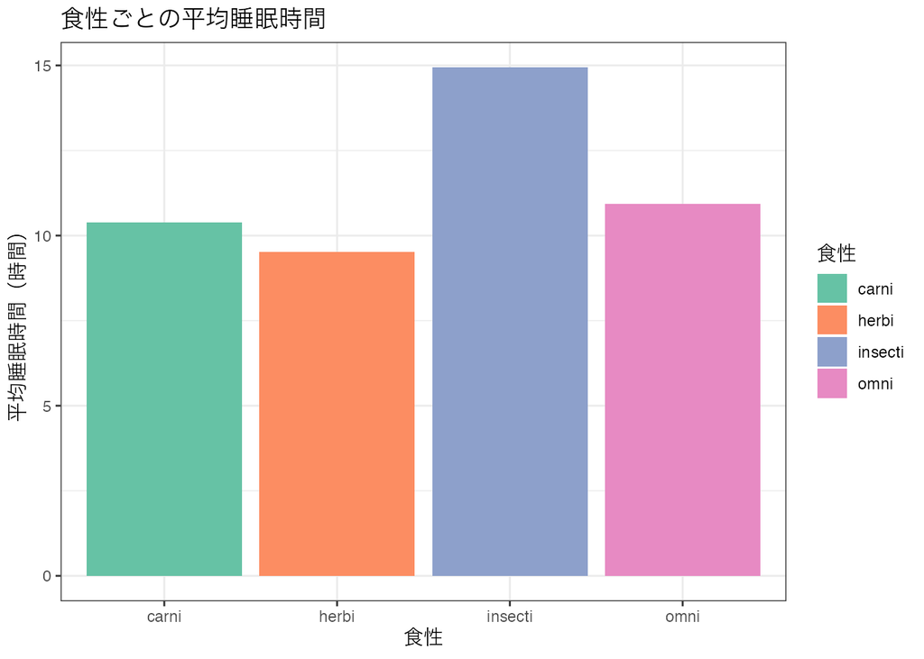

```r
# 集計データを作成
sleep_summary <- msleep |>
  filter(!is.na(vore)) |>
  group_by(vore) |>
  summarise(
    mean_sleep = mean(sleep_total, na.rm = TRUE),
    sd_sleep   = sd(sleep_total, na.rm = TRUE),
    n          = n()
  )

# 棒グラフ（geom_col で集計済みデータを使う）
ggplot(sleep_summary, aes(x = vore, y = mean_sleep, fill = vore)) +
  geom_col() +
  scale_fill_brewer(palette = "Set2") +
  labs(title = "食性ごとの平均睡眠時間",
       x = "食性", y = "平均睡眠時間（時間）",
       fill = "食性") +
  theme_bw()
```

### エラーバー付き棒グラフ

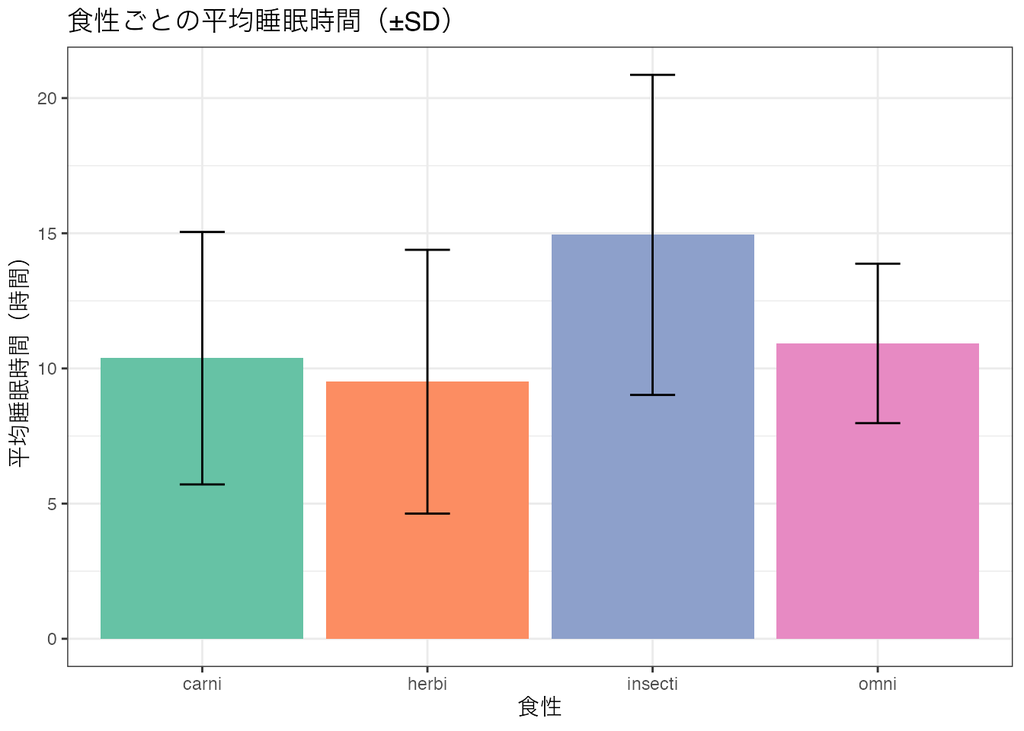

```r
ggplot(sleep_summary, aes(x = vore, y = mean_sleep, fill = vore)) +
  geom_col() +
  geom_errorbar(aes(ymin = mean_sleep - sd_sleep,
                    ymax = mean_sleep + sd_sleep),
                width = 0.2) +
  scale_fill_brewer(palette = "Set2") +
  labs(title = "食性ごとの平均睡眠時間（±SD）",
       x = "食性", y = "平均睡眠時間（時間）") +
  theme_bw() +
  theme(legend.position = "none")
```

## 5. 欠損値の扱い

```r
# 欠損値がある列の確認
msleep |>
  summarise(across(everything(), ~ sum(is.na(.))))
```

| name | genus | vore | order | conservation | sleep_total | sleep_rem | sleep_cycle | awake | brainwt | bodywt |
| --- | --- | --- | --- | --- | --- | --- | --- | --- | --- | --- |
| 0 | 0 | 7 | 0 | 29 | 0 | 22 | 51 | 0 | 27 | 0 |

> **この1行は，今日はじめて出てきた書き方です。読み方だけ説明します。**

> 3つの部品に分かれます。
> - `everything()` … **全部の列**，という意味です
> - `across(列の選び方, かける処理)` … 選んだ列**すべてに同じ処理**をかけます
> - `~ sum(is.na(.))` … かける処理の中身です

> `~`（チルダ）は第4回の `facet_wrap(~ Species)` で出てきた記号ですが， ここでの役目は違います。**「このあとに処理の中身を書きます」という印**です。 そして `.`（ピリオド1つ）が，**いま処理している列**に置き換わります。

> 全体で「**全部の列について，欠損がいくつあるか数える**」と読みます。

> 1列だけ数えたいなら，この書き方は要りません。

> ```r
> sum(is.na(msleep$sleep_rem))   # 22
> ```

> **`across()` を自分で書けるようになる必要は，今日はありません。** 「全部の列をいちどに処理する書き方がある」ことだけ分かれば十分です。

```r
# 欠損値を除いて集計（na.rm = TRUE）
msleep |>
  summarise(mean_rem = mean(sleep_rem, na.rm = TRUE))
```

| mean_rem |
| --- |
| 1.87541 |

> **`n()` と `na.rm = TRUE` を並べるときは注意してください。**

> `n()` は**行数**を数えるだけで，欠損があるかどうかは見ていません。 一方 `mean(x, na.rm = TRUE)` は欠損を除いて計算します。 つまり同じ `summarise()` の中に並べると，**`n` と「平均に使われた件数」がずれます。**

> ```r
> msleep |>
>   summarise(n = n(), mean_brain = mean(brainwt, na.rm = TRUE))
> # n は 83 と出るが，平均に使われたのは 56 件（brainwt は27件が欠損）
> ```

> 実際に使われた件数を数えたいときは `sum(!is.na(brainwt))` を使います。 レポートや論文で n を書くときは，**どちらの数字なのかをはっきりさせてください。**

```r
# 欠損値のある行を除いてから集計
msleep |>
  filter(!is.na(sleep_rem)) |>
  group_by(vore) |>
  summarise(
    n = n(),
    mean_rem = mean(sleep_rem)
  )
```

| vore | n | mean_rem |
| --- | --- | --- |
| carni | 10 | 2.290000 |
| herbi | 24 | 1.366667 |
| insecti | 4 | 3.525000 |
| omni | 18 | 1.955556 |
| NA | 5 | 1.880000 |

## 6. 実際のCSVファイルの読み込み

ここまではRに最初から入っているデータを使ってきました。 自分で集めたデータを読み込むときは，次のように書きます。

```r
# CSVファイルの読み込み（readr パッケージ，tidyverse に含まれる）
my_data <- read_csv("data/my_data.csv")
```

> **`"data/my_data.csv"` の `data/` は，プロジェクトフォルダの中のサブフォルダです。**

> プロジェクトフォルダに `data` という名前のフォルダを作り，その中にCSVを入れてください。 置き場所が違うと，こうなります。

> ```
> Error: 'data/my_data.csv' does not exist in current working directory:
> '/Users/あなたの名前/kodo-keiryo'.
> ```

> **後ろに出ているのが，Rがいま見ているフォルダ**です。 ここに `data` フォルダがあるか，その中にそのファイル名があるかを確かめてください。 いまどこにいるかは `getwd()` で確認できます（第3回の0-1）。

> フォルダを作るのが面倒なら，**プロジェクトフォルダに直接置いて `read_csv("my_data.csv")`** でも構いません。`data/` を付けるのは，ファイルが増えたときに散らからないようにするためだけです。

> **Windowsでパスをコピーしてきた人は，`\` を `/` に直してください。** `"C:\Users\...\my_data.csv"` はエラーになります。`"C:/Users/.../my_data.csv"` と書きます。

### 練習用のファイル

ここから先は，手を動かしながら読んでください。 第5回で使った `msleep` を，**列名を日本語にして**CSVにしたものを2つ置いてあります。 **中身はまったく同じで，文字コードだけが違います。**

> **→ msleep_ja_utf8.csv をダウンロード**（UTF-8・83行6列）

> **→ msleep_ja_cp932.csv をダウンロード**（CP932・83行6列）

> 列は `動物名`・`食性`・`睡眠時間`・`REM睡眠`・`体重`・`脳重量` の6つです。 欠損もそのまま入っています（`REM睡眠` 22件，`脳重量` 27件，`食性` 7件）。

> プロジェクトフォルダに `data` フォルダを作って，その中に2つとも入れてください。

まずUTF-8版です。何も足さずに読めます。

```r
my_data <- read_csv("data/msleep_ja_utf8.csv")
my_data
```

```
# A tibble: 83 × 6
  動物名          食性  睡眠時間 REM睡眠  体重  脳重量
  <chr>           <chr>    <dbl>   <dbl> <dbl>   <dbl>
1 Cheetah         carni     12.1    NA   50    NA
2 Owl monkey      omni      17       1.8  0.48  0.0155
3 Mountain beaver herbi     14.4     2.4  1.35 NA
# ℹ 80 more rows
```

日本語の列名がそのまま使えます。`group_by()` にも引用符なしで渡せます。

```r
my_data |>
  group_by(食性) |>
  summarise(n = n(), 平均 = mean(睡眠時間), sd = sd(睡眠時間))
```

```
# A tibble: 5 × 4
  食性        n  平均    sd
  <chr>   <int> <dbl> <dbl>
1 carni      19 10.4   4.67
2 herbi      32  9.51  4.88
3 insecti     5 14.9   5.92
4 omni       20 10.9   2.95
5 <NA>        7 10.2   3.00
```

### 日本語が化けるとき ―― 文字コードの問題

`read_csv()` は **UTF-8** という文字コードを前提にしています。 ところが **Windows版のExcelで「CSV（コンマ区切り）」として保存すると，多くの場合 Shift_JIS（CP932）になります。** この食い違いが起きると，日本語が読めなくなります。

さきほどと同じことを，CP932版のファイルでやってみてください。

```r
my_data <- read_csv("data/msleep_ja_cp932.csv")
my_data
```

```
# A tibble: 83 × 6
 make.names(x) でエラー:
   '<93><ae><95><a8><96><bc>' に不正なマルチバイト文字があります
```

**`# A tibble: 83 × 6` までは出ています。** つまり**読み込み自体は成功していて， 表示しようとした段階で止まっています。** `<93><ae><95><a8><96><bc>` は `動物名` をCP932で書いたときのバイトの並びです。Rはこれをそのまま列名にしようとして， 「UTF-8として読めない並びだ」と言っています。

> **出方は1通りではありません。**

> いまのように**エラーで止まる**こともあれば，**止まらずに記号で表示される**こともあります。 分かれ目は，**化けているのが列名なのか，データの値なのか**です。 列名がアルファベットで値だけが日本語だと，こうなります。

> ```
> # A tibble: 2 × 2
>   area                   n
>   <chr>              <dbl>
> 1 "\x93\x8c\x8b\x9e"    10
> 2 "\x8eD\x96y"          20
> ```

> `東京` `札幌` と出るはずのところが `\x` で始まる記号になっています。 **こちらはエラーになりません。** 気づかないまま集計や作図に進んでしまい， グラフの軸ラベルが記号だらけになって初めて気づく，ということが起きます。

> **どちらも原因は同じ**で，ファイルの文字コードとRの前提が食い違っているだけです。 エラーが出たかどうかで判断せず，**読み込んだ直後に必ず中身を表示して， 日本語が読めているか確認してください。**

> 使う関数でも変わります。`read.csv()`（R本体の関数，第5回で使いました）は， 値だけが日本語の場合でもエラーで止まります。

対処は2つあります。

**① 読み込むときに文字コードを指定する**

```r
# Windows版Excelで保存したCSVは，たいていこちら
my_data <- read_csv("data/msleep_ja_cp932.csv", locale = locale(encoding = "CP932"))
my_data
```

```
# A tibble: 83 × 6
  動物名          食性  睡眠時間 REM睡眠  体重  脳重量
  <chr>           <chr>    <dbl>   <dbl> <dbl>   <dbl>
1 Cheetah         carni     12.1    NA   50    NA
2 Owl monkey      omni      17       1.8  0.48  0.0155
3 Mountain beaver herbi     14.4     2.4  1.35 NA
# ℹ 80 more rows
```

UTF-8版と同じ表示になりました。**ファイルは書き換えていません。** 「このファイルはCP932で書かれている」とRに教えただけです。

**② 保存するときにUTF-8にしておく（こちらを推奨）**

Excelの「名前を付けて保存」で，ファイルの種類を **`CSV UTF-8 (コンマ区切り)`** にします。 こうしておけば `read_csv()` に何も足さずに読めますし，他の人とデータを共有するときも安全です。

> どちらの文字コードか分からないときは，まず `read_csv()` だけで試してください。 化けていたら `locale = locale(encoding = "CP932")` を足す，という順番で構いません。

### Excelファイルを直接読む方法もあります

`.xlsx` のまま読めば，**文字コードの問題は起きません。**

```r
# install.packages("readxl")   # 最初の1回だけ
library(readxl)

my_data <- read_excel("data/my_data.xlsx")

# シートを指定する場合
my_data <- read_excel("data/my_data.xlsx", sheet = "データ")
```

Excelで管理しているデータなら，CSVに変換せずこちらのほうが確実です。

> `readxl` は tidyverse に含まれていないので，`install.packages("readxl")` が別に必要です。

## 演習

### 演習1：グループ別集計

`iris` データを使って，種（`Species`）ごとに以下を計算してください。

- `Petal.Length` の平均・標準偏差・サンプルサイズ

```r
iris |>
  group_by(___) |>
  summarise(
    n    = n(),
    mean = mean(___),
    sd   = sd(___)
  )
```

### 演習2：集計結果のグラフ化

演習1で作った集計結果を使って，エラーバー付きの棒グラフを作成してください。

```r
# まず集計
petal_summary <- iris |>
  group_by(Species) |>
  summarise(
    mean_petal = mean(Petal.Length),
    sd_petal   = sd(Petal.Length)
  )

# グラフ
ggplot(petal_summary, aes(x = ___, y = ___, fill = ___)) +
  geom_col() +
  geom_errorbar(aes(ymin = ___ - ___, ymax = ___ + ___), width = 0.2) +
  scale_fill_brewer(palette = "Set2") +
  labs(title = "種ごとの花びらの長さ（平均±SD）",
       x = "___", y = "___") +
  theme_bw()
```

### 演習3：count()の応用

`msleep` の食性（`vore`）ごとのサンプルサイズを `count()` で集計し，多い順に並べてください。

> `vore` には欠損値（`NA`）が**7件**あります。`count()` はそのまま使うと `NA` も1つのカテゴリとして数えます。**今回は `NA` を除いて集計してください。**

### 演習4（発展）：自分の関心のあるデータで，同じことをやってみる

今日の手順は，`iris` と `msleep` 以外のデータでもそのまま通じます。 **自分が気になるデータを1つ選んで**，同じことをやってみてください。

#### データの探し方

> **探し方の詳しい手順**は第3回「自分でデータを探す」にまとめてあります。 `data()` で一覧，`?データ名` で説明，`glimpse(データ名)` で中身が見られます。

> 選ぶ条件は，**データフレームであること**（`is.data.frame()` が `TRUE`）と， **グループを表す列と数値の列が1つずつ以上あること**の2つです。 `Titanic` や `HairEyeColor` は表（`table`）なので，この回では選べません。

> 第3回では「数値の列が2つ以上」としていましたが，あれは散布図を描くためです。 **今日はグループごとの平均を出すだけなので，数値の列は1つあれば足ります。**

#### 見つからないときは，この中から選んでください

| データ | 中身 | グループの列 | 数値の列 |
| --- | --- | --- | --- |
| `penguins` | 南極のペンギン344羽の測定 | `species`・`island`・`sex` | `body_mass`・`flipper_len` |
| `ToothGrowth` | モルモット60匹のビタミンC実験 | `supp`・`dose`（`dose` は数値） | `len`（歯の伸び） |
| `ChickWeight` | ヒヨコの成長578件 | `Diet`（4種類の餌） | `weight`・`Time` |
| `InsectSprays` | 殺虫剤6種の効き目72件 | `spray` | `count`（残った虫の数） |
| `warpbreaks` | 織機の糸切れ54件 | `wool`・`tension` | `breaks`（切れた回数） |
| `airquality` | ニューヨークの大気153日分 | `Month`（数値） | `Ozone`（**欠損37件**）・`Temp` |
| `starwars` | 登場人物87人 | `sex` | `height`・`mass`（**欠損28件**） |

**欠損のあるデータ**（`penguins`・`airquality`・`starwars`）を選ぶと， 今日の5節でやった `na.rm` の話がそのまま出てきます。おすすめです。

> **グループの列が「数値」のときは，`factor()` で囲んでください。**

> `airquality` の `Month`（5〜9）や `ToothGrowth` の `dose`（0.5・1・2）は， カテゴリのように見えますが，**Rから見ると数値**です。 そのまま `fill =` に渡すと，棒に色を塗る段階で止まります。

> ```
> Error: Continuous value supplied to a discrete scale.
> ℹ Example values: 5, 6, 7, 8, and 9.
> ```

> 「段階ごとに色を塗る指定（`scale_fill_brewer()`）に，連続した数値が来ました」という意味です。 `factor()` で囲むと，「この列はカテゴリです」とRに伝えられます。

> ```r
> airquality |>
>   group_by(month = factor(Month)) |>
>   summarise(
>     n    = n(),
>     mean = mean(Ozone, na.rm = TRUE),
>     sd   = sd(Ozone, na.rm = TRUE)
>   )
> ```

> `group_by(month = factor(Month))` は，「`Month` をカテゴリに変えたものを `month` と呼んで， それで分ける」という書き方です。 文字の列（`species`・`spray`・`supp` など）は最初からカテゴリなので，何もしなくて大丈夫です。

> **`starwars` を選ぶ人は，ここだけ先に知っておいてください。**

> `sex` で分けると，**1件しかないグループ**が出ます（`hermaphroditic`，ジャバ・ザ・ハット1人）。 1件では標準偏差が計算できないので `sd` が `NA` になり，**その棒だけエラーバーが描かれません。** しかもその1人の体重が1358kgなので，棒グラフの縦軸がその1本に引っ張られて， 他のグループの差が見えなくなります。

> 除いても，残したままでも構いません。**どちらにしたかを問1に書いてください。**

#### やること

1. 選んだデータで，**グループごと**に，数値の列の**件数・平均・標準偏差**を求める
2. 1 の結果を使って，**エラーバー付きの棒グラフ**を描く
3. `count()` で**グループごとの件数**を数え，多い順に並べる

**穴埋めはありません。** 今日のコードの，データ名と列名を置き換えれば動きます。

#### 問

**問1**：なぜそのデータを選びましたか。1〜2行で書いてください。

**問2**：選んだデータに欠損はありましたか。 あった場合，`na.rm = TRUE` を**付ける前と後**で結果はどう変わりましたか。 なかった場合は，上の表から**欠損のあるデータ**を1つ選んで試してみてください。

**問3**：3 で出たグループごとの件数の差は，何を表していますか。 **「世の中の割合」ですか，それとも「データの集め方」ですか。** 第3回で `iris` がどの種も50本ずつだったことを思い出してください。

## この回で使った関数

出てきた順に並べています。**（）の中に何を入れるか**を確かめたいときに見てください。

| 関数 | すること | （）の中に入れるもの | 例 |
| --- | --- | --- | --- |
| `library()` | パッケージを読み込む | パッケージ名。**引用符なし** | `library(tidyverse)` |
| `summarise()` | グループごとに1行にまとめる | データ, `新しい列名 = 集計の式` | `summarise(msleep, 平均 = mean(sleep_total))` |
| `mean()` | 平均 | 数値の列。欠損があるときは `na.rm = TRUE` | `mean(iris$Sepal.Length)` |
| `n()` | そのグループの件数 | **何も入れません**（`n()` と書く） | `summarise(msleep, 件数 = n())` |
| `sd()` | 標準偏差 | 数値の列。欠損があるときは `na.rm = TRUE` | `sd(iris$Sepal.Length)` |
| `min()` | 最小値 | 数値の列 | `min(msleep$sleep_total)` |
| `max()` | 最大値 | 数値の列 | `max(msleep$sleep_total)` |
| `group_by()` | グループに分ける | データ, 分ける基準の列 | `group_by(msleep, vore)` |
| `count()` | 件数を数えて表にする | データ, 数える基準の列 | `count(msleep, vore)` |
| `filter()` | **行**を絞り込む | データ, 残す行の条件。`,` で並べると「かつ」 | `filter(msleep, sleep_total >= 12)` |
| `is.na()` | 欠損値かどうか調べる | 列。`!is.na()` で「欠損でない」 | `filter(msleep, is.na(vore))` |
| `ggplot()` | グラフの土台を作る | `data =` データ, `aes()` で軸の割り当て | `ggplot(iris, aes(x = Sepal.Length, y = Petal.Length))` |
| `aes()` | 列をグラフの要素に割り当てる | `x =`, `y =`, `color =`, `fill =` など | `aes(x = Species, y = Petal.Length)` |
| `geom_col()` | 値をそのまま棒の高さにする | `aes(y = 値)` が必要 | `geom_col()` |
| `scale_fill_brewer()` | 塗りつぶしの色をColorBrewerの組にする | `palette = "Set2"` など | `scale_fill_brewer(palette = "Set2")` |
| `labs()` | タイトルや軸ラベルを付ける | `title =`, `x =`, `y =`, `color =`, `fill =` | `labs(title = "花びらの長さ", x = "種", y = "長さ (cm)")` |
| `theme_bw()` | 白地に枠線の見た目にする | **何も入れません**（`base_family =` でフォント指定可） | `theme_bw()` |
| `geom_errorbar()` | エラーバーを描く | `aes(ymin =, ymax =)`, `width =` | `geom_errorbar(aes(ymin = m - s, ymax = m + s), width = 0.2)` |
| `theme()` | 細かい見た目を個別に変える | `axis.text = element_text(...)` など | `theme(axis.text = element_text(size = 12))` |
| `across()` | 複数の列に同じ処理をかける | 列の選び方, かける関数 | `across(where(is.numeric), mean)` |
| `everything()` | 残りの全部の列 | **何も入れません** | `select(msleep, name, everything())` |
| `sum()` | 合計 | 数値の列 | `sum(iris$Sepal.Length)` |
| `read_csv()` | CSVファイルを読み込む | ファイルのパス（引用符あり）。文字化けには `locale =` | `read_csv("data/my_data.csv")` |
| `locale()` | 文字コードなどの読み取り設定 | `encoding = "CP932"` など | `locale(encoding = "CP932")` |
| `read_excel()` | Excelファイルを読み込む | ファイルのパス, `sheet =`（シート名か番号） | `read_excel("data/my_data.xlsx", sheet = 1)` |
| `factor()` | カテゴリ（水準つき）に変える | 元の列, `levels =`（順序）, `labels =`（表示名） | `factor(mtcars$am, labels = c("AT", "MT"))` |

パイプ `|>` は関数ではなく記号です。`データ |> 関数()` と書くと， データがその関数の**1つめの（）の中身**として渡されます。

> **もっと詳しく知りたいときは** `?関数名` と実行してください（例：`?summarise`）。 右下の **Help** タブに，その関数の説明と，（）に書ける項目が全部出ます。 読み方は **第2回「ヘルプの読み方」** にまとめてあります。

## 本日のまとめ

- `summarise()` でデータを集計できる
- `group_by()` と組み合わせるとグループ別集計が可能
- `count()` でカテゴリの頻度を数えられる
- 集計結果を `ggplot2` でグラフ化できる
- `na.rm = TRUE` で欠損値を除いた計算ができる

## 宿題・予習

- 本日の演習を仕上げ，スクリプトを保存しておく
- 次回は**習熟度確認テスト（第1回）**と復習です
- **今日の `group_by()`・`summarise()` も教科書には載っていません。** もっと知りたい人は，**講義指定図書『RユーザのためのRStudio［実践］入門』（改訂2版）**の **3-3〜3-4「dplyrによる基本的／応用的なデータ操作」**へ。**必須ではありません**
- 第2〜6回で学んだ内容（可視化・加工）を見直しておく

← 授業トップへ戻る